# HW 01

Author

S. David Kyle

## 0 - Setup[^1]

```r
if (!require("pacman"))
  install.packages("pacman")
# use this line for installing/loading
pacman::p_load(tidyverse,
               scales,
               openintro,
               cowplot,
               ggrepel,
               readr,
               grid,
               gridExtra)

devtools::install_github("tidyverse/dsbox")
```

## 1 - Road traffic accidents in Edinburgh

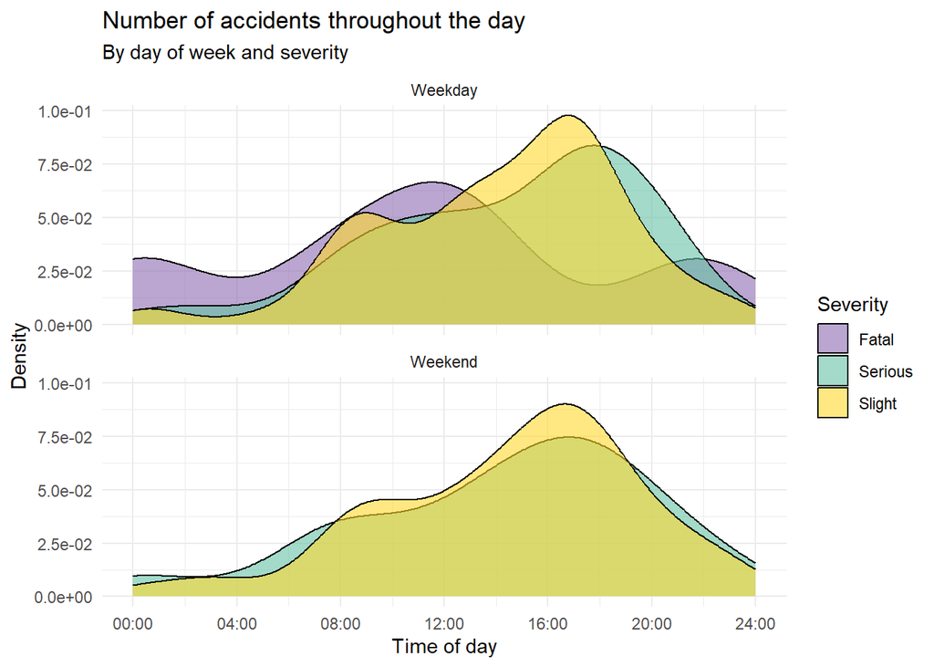

```r
# Load dataset
accidents <- read_csv("data/accidents.csv")
# Prepare variables
accidents <- accidents |>
  mutate(
    date = as.Date(date),
    hour = hour(time) + minute(time) / 60,
    weekday_name = weekdays(date),
    day_type = if_else(
      weekday_name == "Saturday" | weekday_name == "Sunday",
      "Weekend",
      "Weekday"
    )
  )

# Plot using default density (area under curve = 1)
ggplot(accidents, aes(x = hour, fill = severity)) +
  geom_density(aes(group = severity), alpha = 0.6, position = "identity") +
  facet_wrap(~day_type, ncol = 1) +
  scale_fill_manual(
    values = c("Fatal" = "#8c6bb1", "Serious" = "#66c2a5", "Slight" = "#ffd92f")
  ) +
  scale_x_continuous(
    name = "Time of day",
    limits = c(0, 24),
    breaks = seq(0, 24, by = 4),
    labels = sprintf("%02d:00", seq(0, 24, by = 4))
  ) +
  scale_y_continuous(
    name = "Density",
    labels = scientific
  ) +
  labs(
    title = "Number of accidents throughout the day",
    subtitle = "By day of week and severity",
    fill = "Severity"
  ) +
  theme_minimal()
```

```r
# Count and print the number of fatal weekend accidents
accidents |>
  filter(severity == "Fatal", day_type == "Weekend") |>
  nrow()
```

```
[1] 0
```

```r
# Am I missing weekend fatalities
table(accidents$severity, accidents$day_type)
```

```
          Weekday Weekend
  Fatal         5       0
  Serious      80      35
  Slight      461     187
```

### Interpretation

We draw a density plot to normalize the data between weekday and weekend traffic, allowing for meaningful comparison despite differences in overall traffic volume.

- There are visible peaks around 16:00 in both plots, corresponding to the end of the workday when traffic tends to be heaviest.
- The weekday plot also shows a peak around 08:00, likely reflecting the morning commute.
- A small peak in fatal accidents around 11:00 on weekdays may be related to delivery vehicles or mid-morning traffic patterns, though this would need further investigation to confirm.
- There are no fatal accidents recorded on weekends in this dataset. This could be due to reduced traffic volume, safer driving conditions, or simply random variation in a single year of data. A reporting issue is also possible, though the rest of the dataset appears complete.

## 2 - NYC marathon winners

### a.

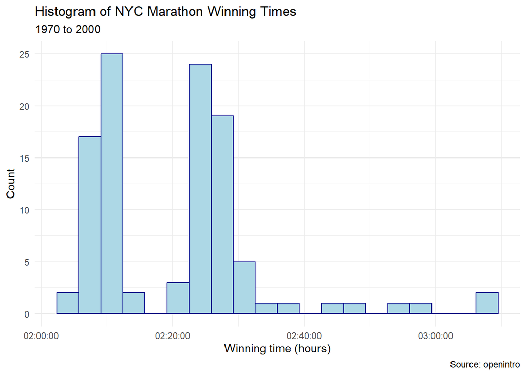

```r
# Drop all non-finite times
nyc_clean <- nyc_marathon |>
  filter(is.finite(time))

# Histogram
nyc_clean |>
  ggplot(aes(x = time)) +
  geom_histogram(bins = 20, color="darkblue", fill="lightblue") +
  labs(
    title = "Histogram of NYC Marathon Winning Times",
    subtitle = "1970 to 2000",
    caption = "Source: openintro",
    x     = "Winning time (hours)",
    y     = "Count"
  ) +
  theme_minimal()
```

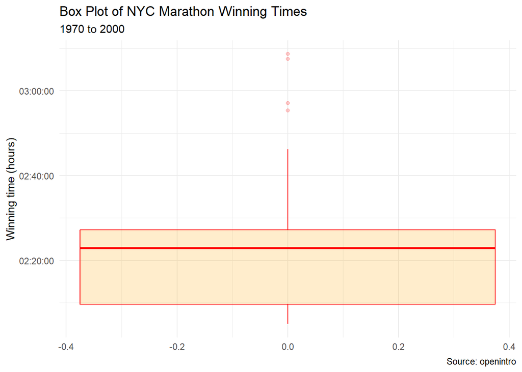

```r
# Box plot
nyc_clean |>
  ggplot(aes(y = time)) +
  geom_boxplot(color="red", fill="orange", alpha=0.2) +
  labs(
    title = "Box Plot of NYC Marathon Winning Times",
    subtitle = "1970 to 2000",
    caption = "Source: openintro",,
    y     = "Winning time (hours)"
  ) +
  theme_minimal()
```

The box plot gives you the exact quartiles, whisker-range and marks outliers, the histogram does not.

### b.

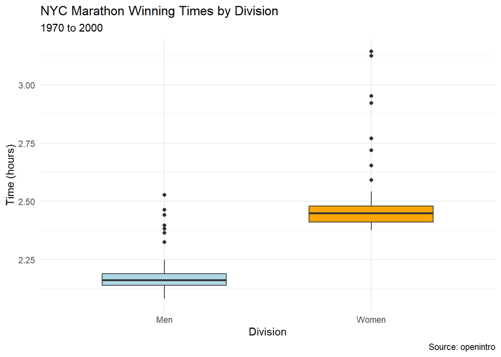

```r
# Side-by-side box plots
nyc_clean |>
  ggplot(aes(
    x    = division,
    y    = time_hrs,
    fill = division
  )) +
  geom_boxplot(width = 0.6) +
  scale_fill_manual(values = c(
      Men   = "lightblue", Women = "orange"
    )) +
  labs(
    title = "NYC Marathon Winning Times by Division",
    subtitle = "1970 to 2000",
    caption = "Source: openintro",
    x     = "Division",
    y     = "Time (hours)"
  ) +
  theme_minimal() +
  theme(legend.position = "none")
```

Men’s times have a faster median with fewer extreme values, women’s times have a slower median, with more variance.

### c.

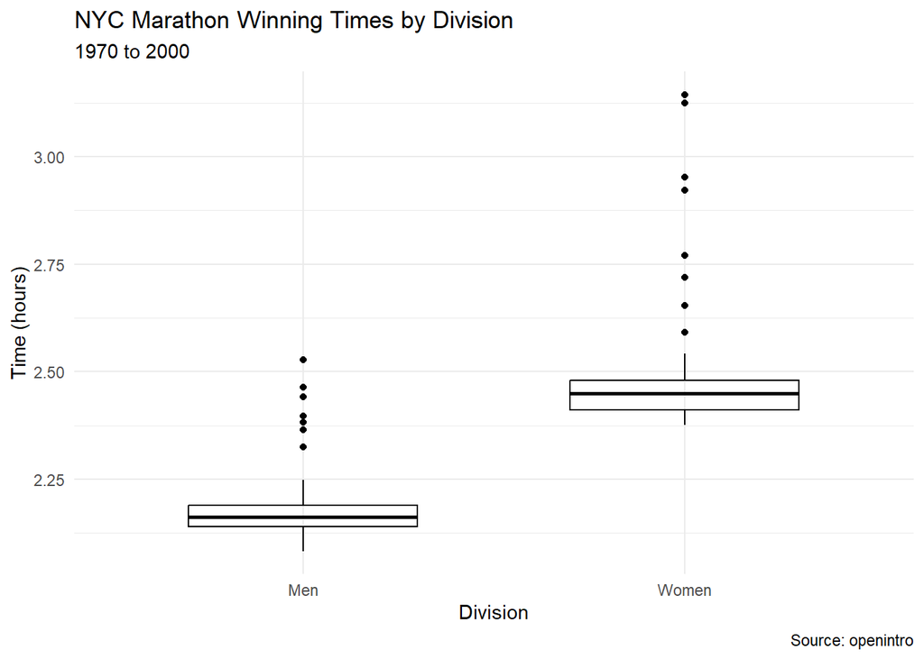

```r
nyc_clean |>
  ggplot(aes(
    x    = division,
    y    = time_hrs,
    fill = division
  )) +
  geom_boxplot(
    width = 0.6,
    fill  = NA,       # no fill color
    color = "black"   # box outlines in black
  ) +
  labs(
    title = "NYC Marathon Winning Times by Division",
    subtitle = "1970 to 2000",
    caption = "Source: openintro",
    x     = "Division",
    y     = "Time (hours)"
  ) +
  theme_minimal() +
  theme(legend.position = "none")
```

I removed box colors as it could be seen as duplicate indication on the x-axis and does remove ink in a sense. It is all I could figure to remove, there just isn’t much on the chart. I believe my chart is an incorrect chart and colors should be used.

It is possible that in some charts a legend was presented initially. This should be removed as it is unnecessary.

### d.

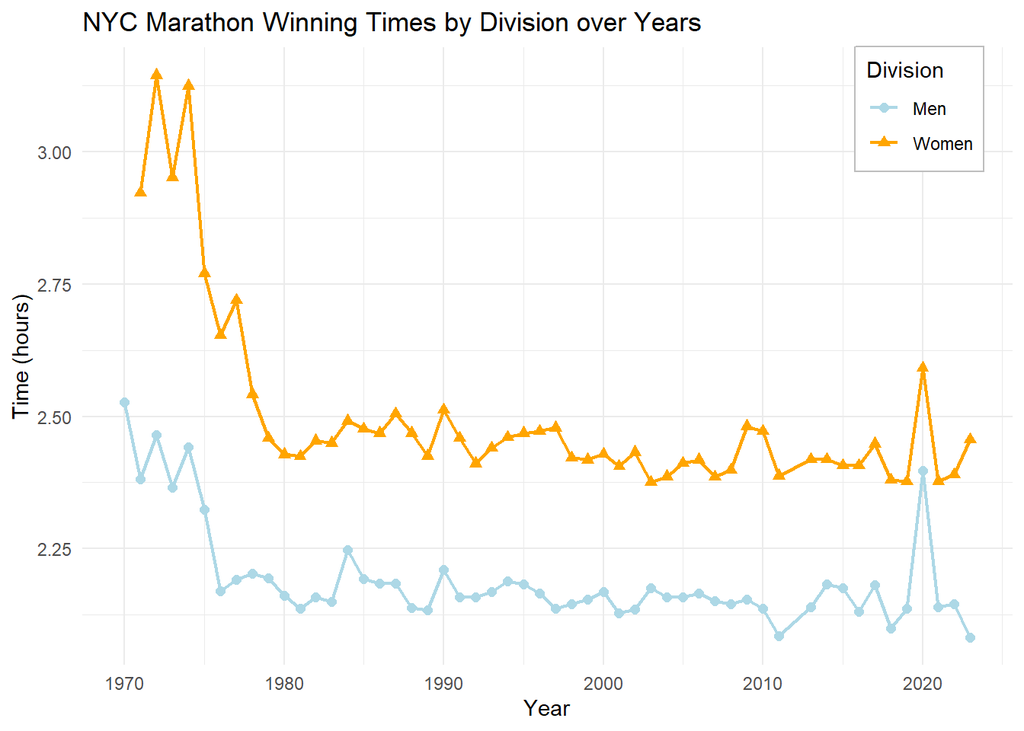

```r
nyc_clean |>
  ggplot(aes(
      x     = year,
      y     = time_hrs,
      color = division,
      shape = division,
      group = division
    )) +
    geom_line(size = 0.8) +
    geom_point(size = 2) +
    scale_color_manual(
      values = c(
        Men   = "lightblue",
        Women = "orange"
      )
    ) +
    scale_shape_manual(
      values = c(
        Men   = 16,
        Women = 17
      )
    ) +
    labs(
      title = "NYC Marathon Winning Times by Division over Years",
      x     = "Year",
      y     = "Time (hours)",
      color = "Division",
      shape = "Division"
    ) +
    theme_minimal() +
    theme(
      legend.position = c(0.9, 0.9),
      legend.box.background = element_rect(fill = "white", color = "grey")
    )
```

Trends over time are shown in this graph and not in the others. The times for both divisions improved at first rapidly then over time steadily. There is an increase in times for 2020 very likely due to COVID.

## 3 - US counties

### a.

```r
# First, clean the data
county_clean <-
  county %>%
  filter(
    !is.na(pop2017),
    !is.na(median_edu)
  )
```

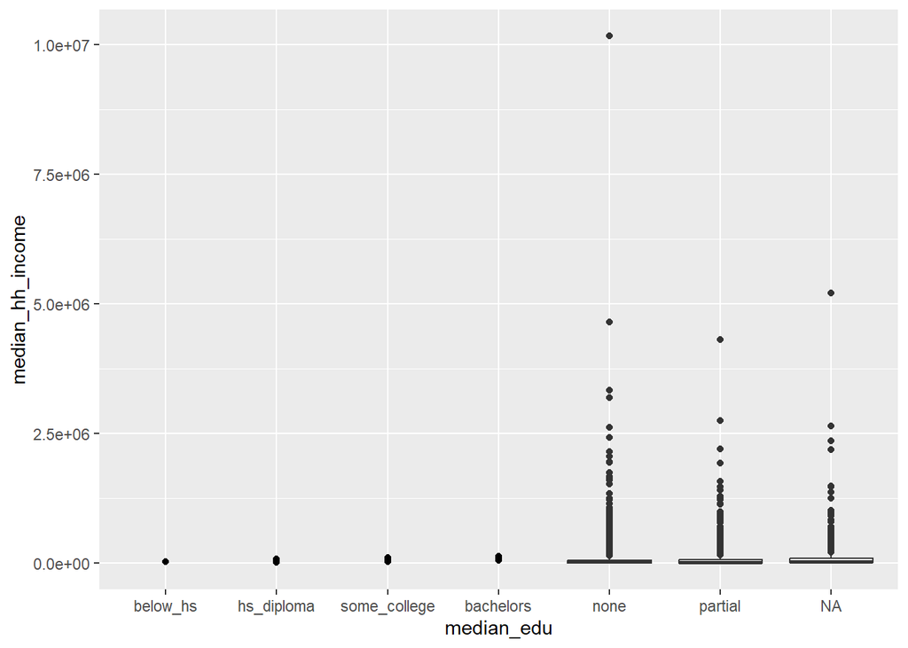

```r
# These are entirely different plots
ggplot(county_clean) +
  geom_point(aes(x = median_edu, y = median_hh_income)) +
  geom_boxplot(aes(x = smoking_ban,  y = pop2017))
```

This plot doesn’t work at all. Two different plots on the same axis in this case does not convey much if any meaningful information.

### b.

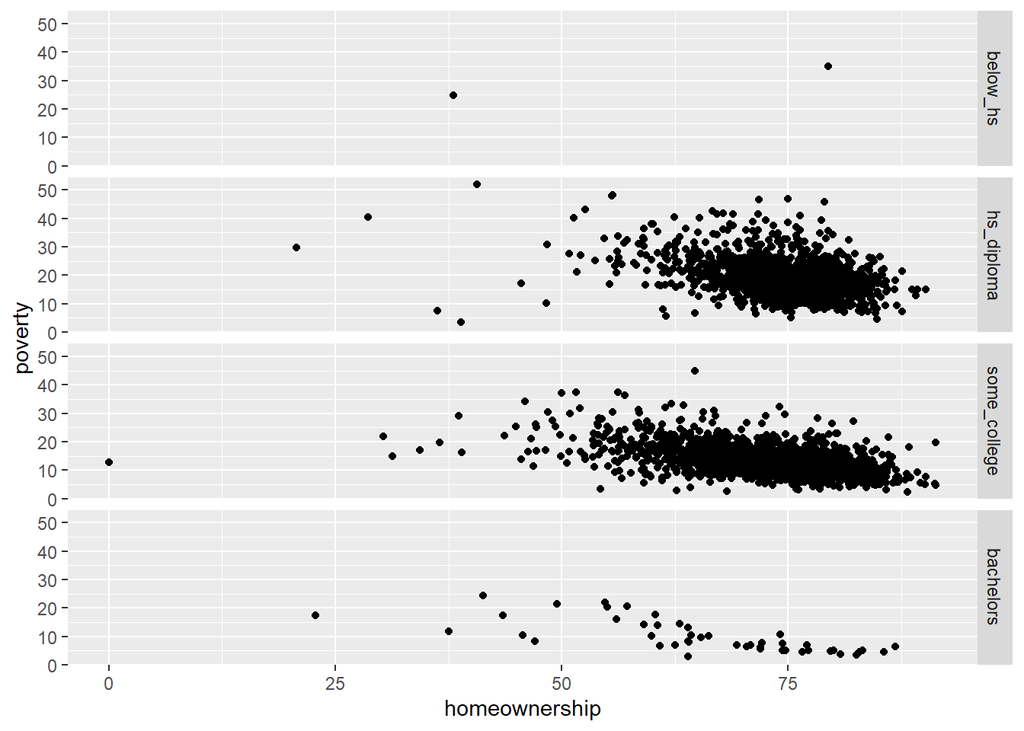

```r
# Cleaning data on the fly and faceting on median_edu
ggplot(county %>% filter(!is.na(median_edu))) +
  geom_point(aes(x = homeownership, y = poverty)) +
  facet_grid(median_edu ~ .)
```

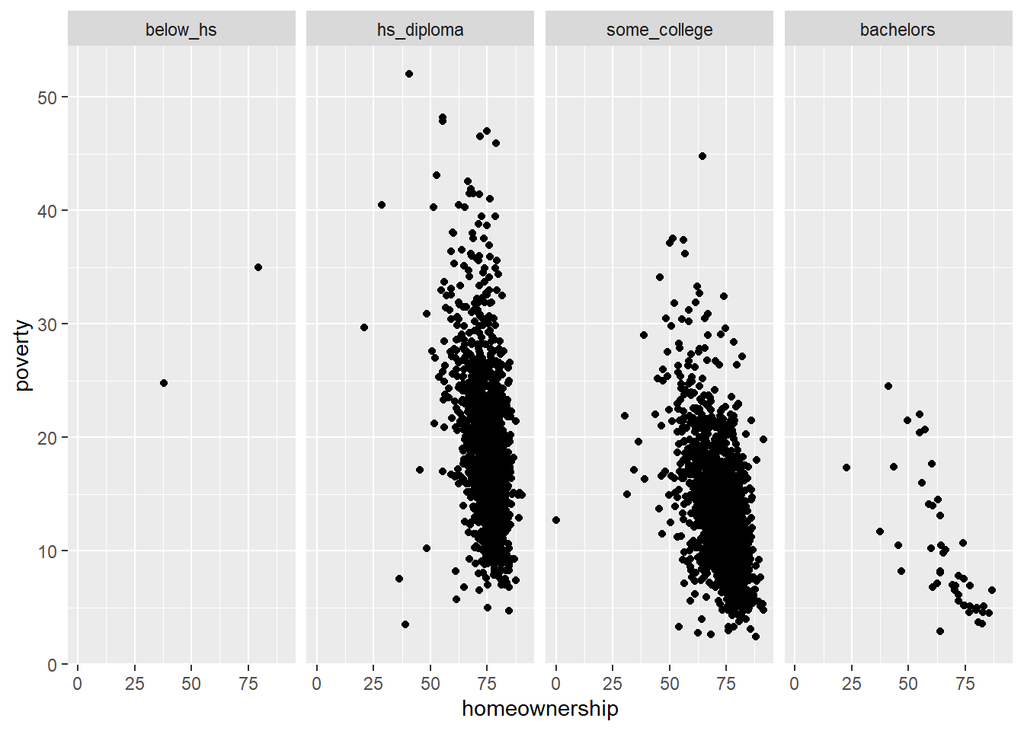

```r
ggplot(county %>% filter(!is.na(median_edu))) +
  geom_point(aes(x = homeownership, y = poverty)) +
  facet_grid(. ~ median_edu)
```

I believe the second plot is easier to identify the relationship to poverty across the groups because there is a single y-scale that can be easily looked at once and compared across those groups. I guess faceting should be done so that the “relationship” property has a single scale. For example, if the question was home ownership, rows would be appropriate.

### c.

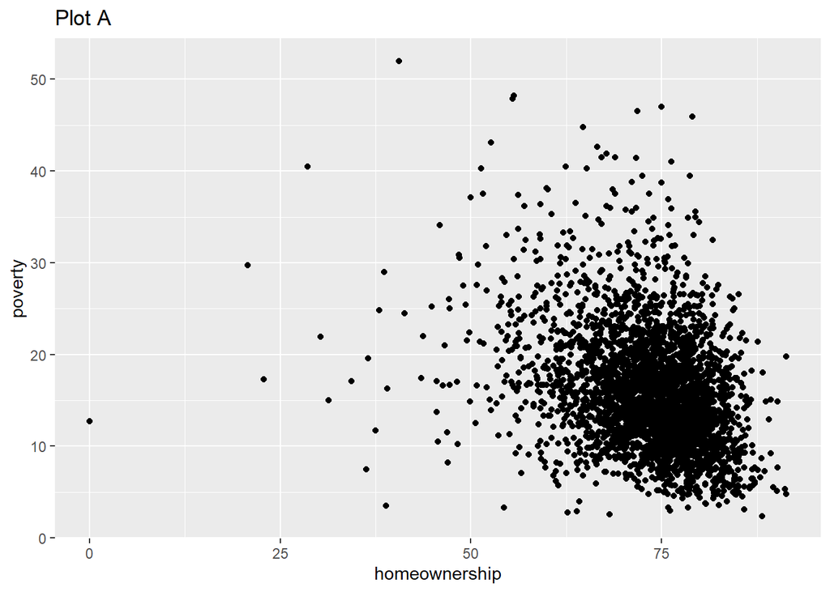

```r
# Sctter of poverty vs. home ownership
ggplot(county_clean, aes(x = homeownership, y = poverty)) +
  geom_point() +
  labs(
      title = "Plot A"
  )
```

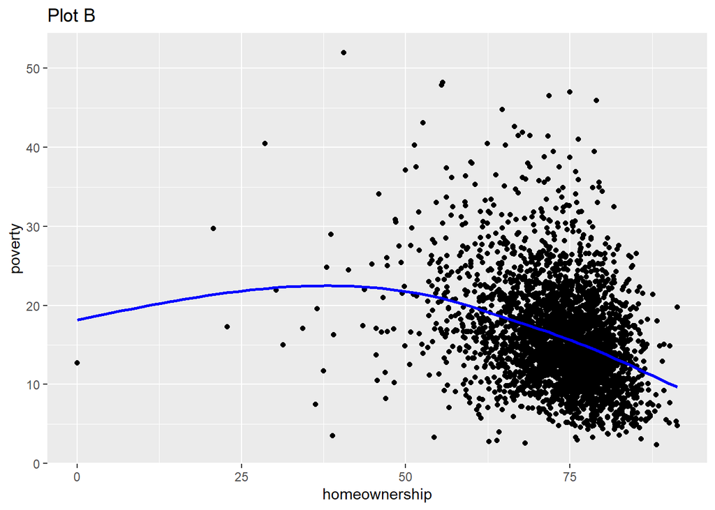

```r
# Add an overall smooth
ggplot(county_clean, aes(x = homeownership, y = poverty)) +
  geom_point() +
  geom_smooth(se = FALSE, color = "blue") +
  labs(
    title = "Plot B"
  )
```

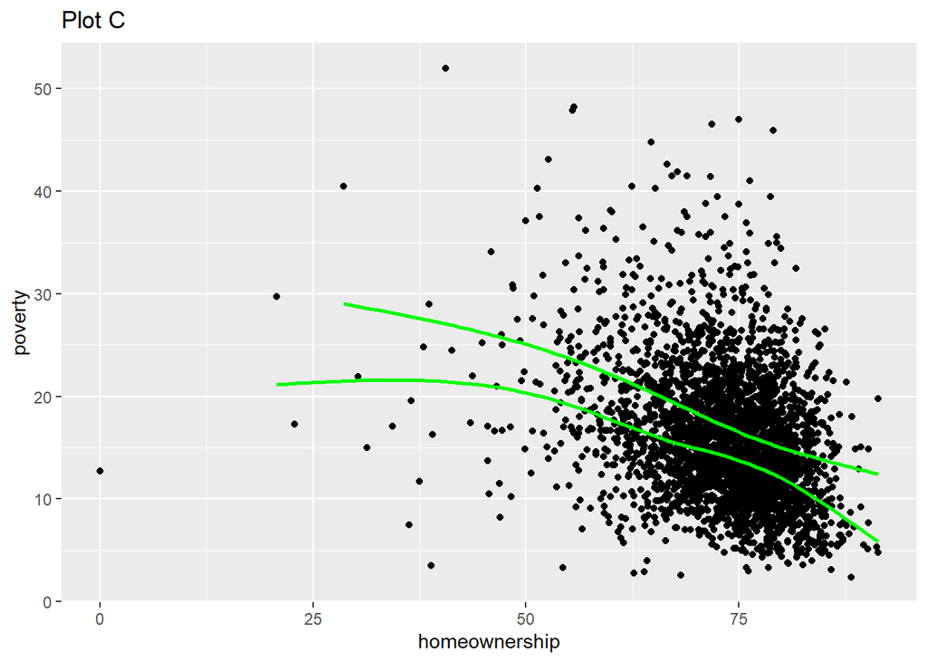

```r
# Scatter plus smoothes for metro
ggplot(county_clean, aes(x = homeownership, y = poverty)) +
  geom_point() +
  geom_smooth(aes(color = metro), se = FALSE) +
  scale_color_manual(values = c(no = "green", yes = "green")) +
  theme(legend.position = "none") + # no legend
  labs(
    title = "Plot C"
  )
```

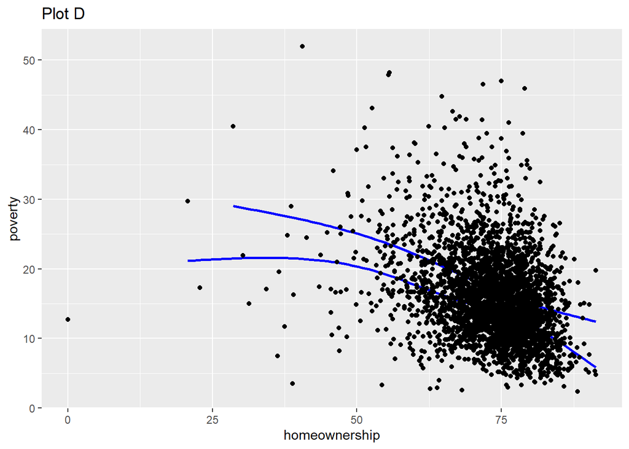

```r
# Scatter plus smoothes for metro. Smoothes are under the scatter
ggplot(county_clean, aes(x = homeownership, y = poverty)) +
  # Draw smooths first
  geom_smooth(
    aes(color = metro),
    se = FALSE
  ) +
  # Draw points on top
  geom_point() +
  scale_color_manual(
    values = c(no = "blue", yes = "blue")
  ) +
  theme(legend.position = "none") +
  labs(
    title = "Plot D"
  )
```

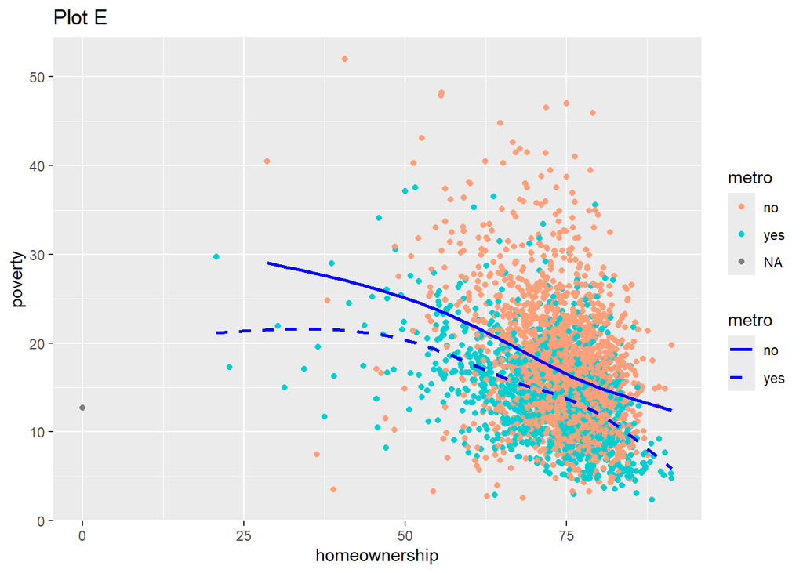

```r
# Scatter with colors by metro. Style smoothes by metro
ggplot(county_clean, aes(x = homeownership, y = poverty)) +
  # Points coloured by metro
  geom_point(aes(color = metro)) +
  # Smoothes all blue, with line type by metro
  geom_smooth(aes(linetype = metro),
              color = "blue",
              se     = FALSE) +
  scale_color_manual(values = c(
    no  = "lightsalmon",
    yes = "darkturquoise"
  )) +
  scale_linetype_manual(values = c(
    no  = "solid",
    yes = "dashed"
  )) +
  labs(
    title = "Plot E"
  )
```

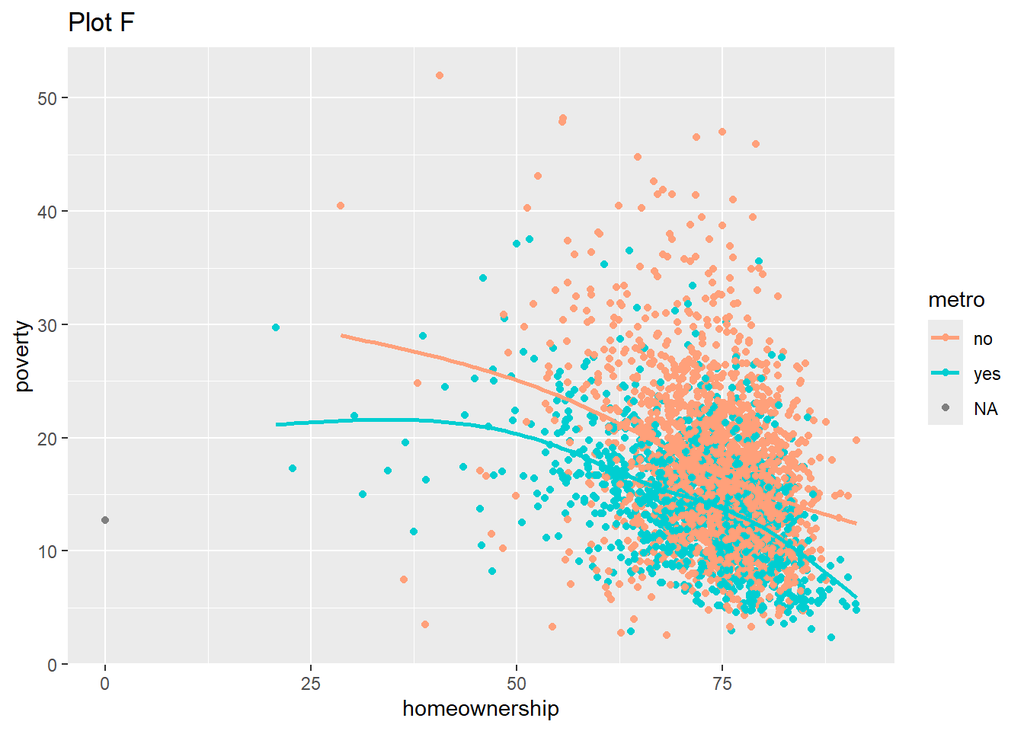

```r
# Scatter with colors by metro. Style smoothes by color by metro
ggplot(county_clean, aes(x = homeownership, y = poverty)) +
  geom_point(aes(color = metro)) +
  geom_smooth(aes(color = metro), se = FALSE) +
  scale_color_manual(values = c(
    no  = "lightsalmon",
    yes = "darkturquoise"
  )) +
  labs(
    title = "Plot F"
  )
```

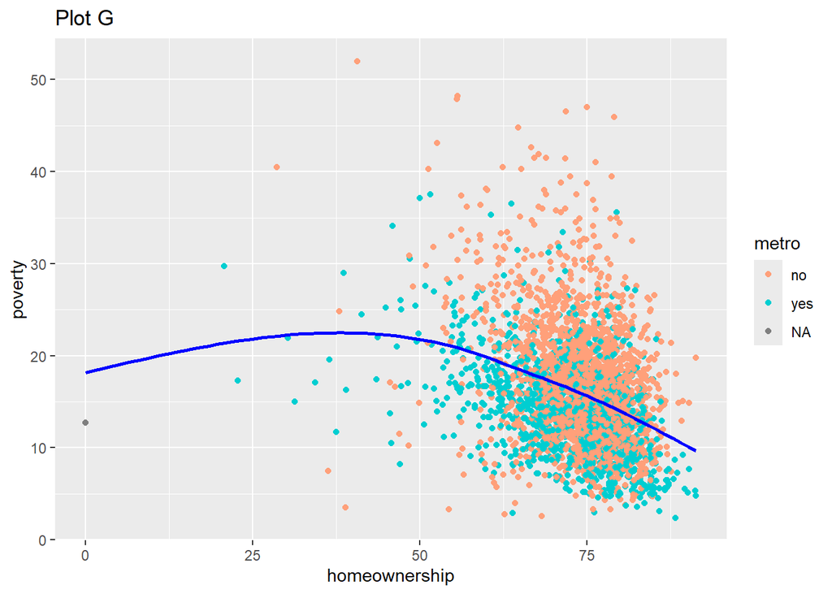

```r
# Scatter with colors by metro. Single smooth
# Bringing it back
ggplot(county_clean, aes(x = homeownership, y = poverty)) +
  geom_point(aes(color = metro)) +
  geom_smooth(aes(group = 1), se = FALSE, color = "blue") +
  scale_color_manual(values = c(
    no  = "lightsalmon",
    yes = "darkturquoise"
  )) +
  labs(
    title = "Plot G"
  )
```

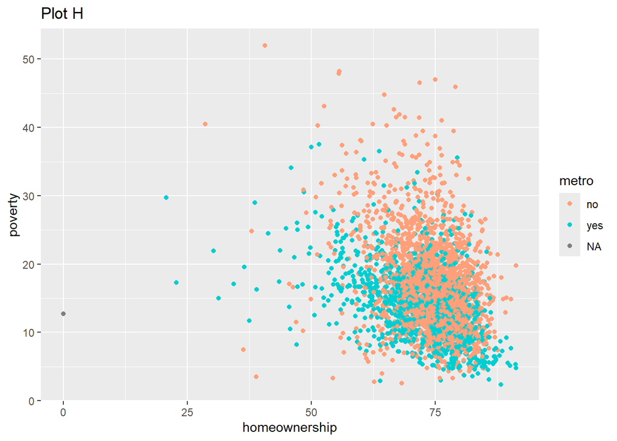

```r
# Scatter with colors by metro
ggplot(county_clean, aes(x = homeownership, y = poverty, color = metro)) +
  geom_point() +
  scale_color_manual(values = c(
    no  = "lightsalmon",
    yes = "darkturquoise"
  )) +
  labs(
    title = "Plot H"
  )
```

## 4 - Rental apartments in SF

### a.

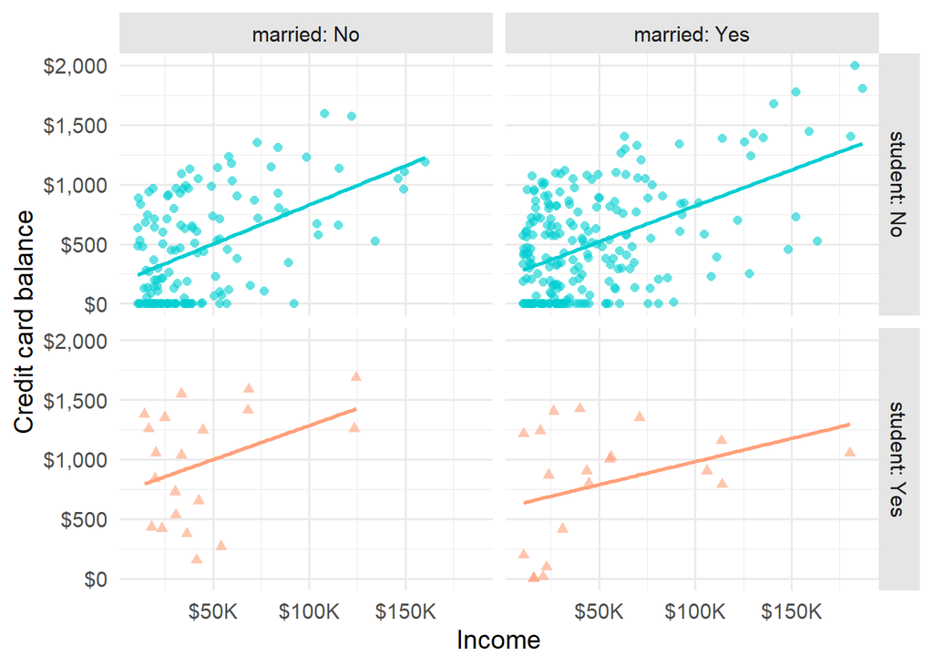

```r
# Load dataset
credit <- read_csv("data/credit.csv", show_col_types = FALSE)

 # The plot
ggplot(credit, aes(x = income, y = balance,
                   color = student, shape = student)) +
  geom_point(alpha = 0.6, size = 2) +
  geom_smooth(method = "lm", se = FALSE) +
  facet_grid(student ~ married, labeller = label_both) +
  scale_color_manual(
    values = c("No"  = "darkturquoise",
               "Yes" = "lightsalmon")
  ) +
  # Add scaling formatting and breaks
  scale_x_continuous(
    labels = dollar_format(prefix = "$", suffix = "K"),
    breaks = seq(0, 200, 50)
  ) +
  scale_y_continuous(labels = dollar_format(prefix = "$")) +
  # Labels
  labs(
    x     = "Income",
    y     = "Credit card balance"
  ) +
  # Standard themeing
  theme_minimal(base_size = 14) +
  theme(
    strip.background  = element_rect(fill = "grey90", color = NA),
    legend.position   = "none"
  )
```

From the plots, income and credit-card balance are positively correlated. Students start with higher balances at lower incomes, which makes sense as they are not earning when they go to school and take on debt. I do not believe I can make a judgement comparing slopes as they seem close and with the limited amount of samples the sample regression may be far from the actual regression.

### b.

I think student would be a predictor for credit card balance. The intercept is clearly higher for students. I hold with my position above that there is not enough data for me to judge if married could be a predictor.

### c.

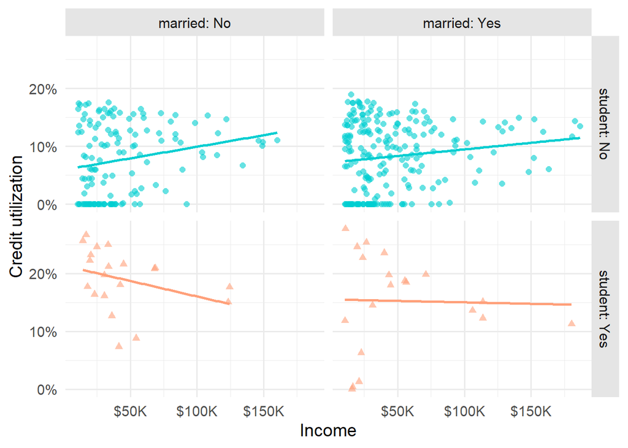

```r
credit_u <- credit |>
  mutate(utilization = balance / limit)

 # The plot
ggplot(credit_u, aes(x = income, y = utilization,
                   color = student, shape = student)) +
  geom_point(alpha = 0.6, size = 2) +
  geom_smooth(method = "lm", se = FALSE) +
  facet_grid(student ~ married, labeller = label_both) +
  scale_color_manual(
    values = c("No"  = "darkturquoise",
               "Yes" = "lightsalmon")
  ) +
  # Add scaling formatting and breaks
  scale_x_continuous(
    labels = dollar_format(prefix = "$", suffix = "K"),
    breaks = seq(0, 200, 50)
  ) +
  scale_y_continuous(
    labels = percent_format(accuracy = 1),
    limits = c(0, NA)
  ) +
  # Labels
  labs(
    x = "Income",
    y = "Credit utilization"
  ) +
  # Standard themeing
  theme_minimal(base_size = 14) +
  theme(
    strip.background  = element_rect(fill = "grey90", color = NA),
    legend.position   = "none"
  )
```

### d.

Compared to the first graph the utilization slope flips for students even though we know credit balance increases. This suggests students have more credit than non-students–I believe this is misleading and actually untrue.

My guess is to what is actually happening is that utilization for students and non-students actually converges to a very similar number at higher incomes. The graph is skewed significantly by the high utilization at low incomes for students. This can be seen with married students as they take on less debt at lower incomes. If just the high end of income is examined this is casually reinforced. More data would really be helpful.

This was a surprisingly interesting exercise.

## 5 - Napoleon’s march.

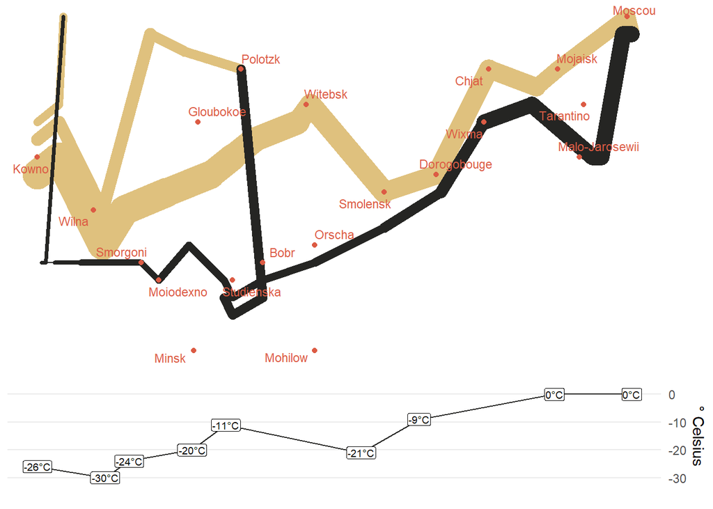

```r
# This code is adapted from the "Exploring Minard’s 1812 plot with ggplot2" blog post by Andrew Heiss

# Load data
napoleon     <- read_rds("data/napoleon.rds")
troops       <- napoleon$troops
cities       <- napoleon$cities
temps.nice   <- napoleon$temperatures %>%
  mutate(nice.label = paste0(temp, "°C"))

# March map panel
march.1812.plot.simple <- ggplot() +
  geom_path(
    data     = troops,
    aes(x = long, y = lat, group = group,
        color = direction, size = survivors),
    lineend  = "round"
  ) +
  geom_point(
    data  = cities,
    aes(x = long, y = lat),
    color = "#DC5B44"
  ) +
  geom_text_repel(
    data  = cities,
    aes(x = long, y = lat, label = city),
    color = "#DC5B44",
    size  = 3
  ) +
  scale_size_continuous(range = c(0.5, 10), guide = "none") +
  scale_colour_manual(
    values = c(advancing = "#DFC17E", retreating = "#252523"),
    guide  = "none"
  ) +
  theme_nothing()

# Temperature “timeline” panel
temps.1812.plot <- ggplot(data = temps.nice, aes(x = long, y = temp)) +
  geom_line(color = "#252523") +
  geom_label(
    aes(label = nice.label),
    size          = 2.5,
    fill          = "white",
    label.padding = unit(0.1, "lines"),
    show.legend   = FALSE
  ) +
  labs(x = NULL, y = "° Celsius") +
  scale_x_continuous(
    limits = ggplot_build(march.1812.plot.simple)$layout$panel_ranges[[1]]$x.range
  ) +
  scale_y_continuous(position = "right") +
  coord_cartesian(ylim = c(-35, 5)) +
  theme_bw() +
  theme(
    panel.grid.major.x = element_blank(),
    panel.grid.minor.x = element_blank(),
    panel.grid.minor.y = element_blank(),
    axis.text.x        = element_blank(),
    axis.ticks         = element_blank(),
    panel.border       = element_blank(),
    legend.position    = "none"
  )

# Stack them & set relative heights
both.1812.plot.simple <- rbind(
  ggplotGrob(march.1812.plot.simple),
  ggplotGrob(temps.1812.plot)
)

# find panel rows and assign a 3:1 height ratio
panels <- both.1812.plot.simple$layout$t[
  grep("panel", both.1812.plot.simple$layout$name)
]
both.1812.plot.simple$heights[panels] <- unit(c(3, 1), "null")

# Draw
grid::grid.newpage()
grid::grid.draw(both.1812.plot.simple)
```

Sources:  
Google  
-General searches for coding issues finding Minard’s plot in ggplot2  
https://www.google.com/  
Napoleon’s Moscow campaign: as told by Charles Minard’s chart  
-Understanding Minard’s plot  
https://www.youtube.com/watch?v=HrEuJO3wz3k&ab_channel=AndyCotgreave  
ChatGPT  
-Explanation of exceptions during coding, queries about how certain code works  
https://chatgpt.com/

Exploring Minard’s 1812 plot with ggplot2 by Andrew Wheiss  
-Source of the code concepts  
https://www.andrewheiss.com/blog/2017/08/10/exploring-minards-1812-plot-with-ggplot2/  
https://github.com/andrewheiss/fancy-minard  
lecture9_nov12-2018  
-Additional exploration of the above blog post  
https://rpubs.com/maypowerss/ggplot2  
A Layered Grammar of Graphics by Hadley Wickham  
-Introduction to ggplot2 with a simple discussion of Minard’s graphic  
https://vita.had.co.nz/papers/layered-grammar.pdf

Data is first loaded into dataframes and temperatures are mutated into a more readable format like “31°C.” The graph consists of two panels a “March Map Panel” and a “Temperature Timeline Panel.” The “March Map Panel” is a layered ggplot. It creates a path for the troops with size representing survivors, it draws points and labels for cities, controls the survivor line thickness, and themes the plot. “Temperature Timeline Plot” is a simple line graph with labels for temperature over time. The plots are stacked and drawn.

All things considered, it ends up being less complicated that initially expected.

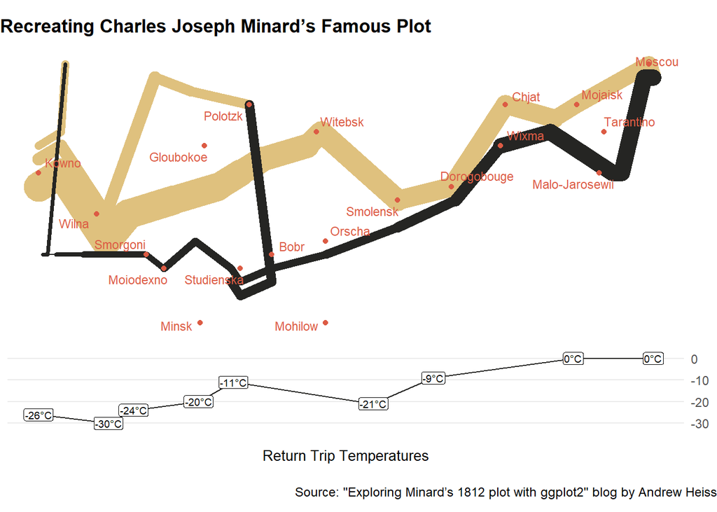

```r
# This code is adapted from the "Exploring Minard’s 1812 plot with ggplot2" blog post by Andrew Heiss

# Load data
napoleon     <- read_rds("data/napoleon.rds")
troops       <- napoleon$troops
cities       <- napoleon$cities
temps.nice   <- napoleon$temperatures %>%
  mutate(nice.label = paste0(temp, "°C"))

# March map panel
march.1812.plot.simple <- ggplot() +
  geom_path(
    data     = troops,
    aes(x = long, y = lat, group = group,
        color = direction, size = survivors),
    lineend  = "round"
  ) +
  geom_point(
    data  = cities,
    aes(x = long, y = lat),
    color = "#DC5B44"
  ) +
  geom_text_repel(
    data  = cities,
    aes(x = long, y = lat, label = city),
    color = "#DC5B44",
    size  = 3
  ) +
  scale_size_continuous(range = c(0.5, 10), guide = "none") +
  scale_colour_manual(
    values = c(advancing = "#DFC17E", retreating = "#252523"),
    guide  = "none"
  ) +
  theme_nothing()

# Temperature “timeline” panel
temps.1812.plot <- ggplot(data = temps.nice, aes(x = long, y = temp)) +
  geom_line(color = "#252523") +
  geom_label(
    aes(label = nice.label),
    size          = 2.5,
    fill          = "white",
    label.padding = unit(0.1, "lines"),
    show.legend   = FALSE
  ) +
  labs(x = NULL, y = NULL, caption = "Return Trip Temperatures") +
  scale_x_continuous(
    limits = ggplot_build(march.1812.plot.simple)$layout$panel_ranges[[1]]$x.range
  ) +
  scale_y_continuous(position = "right") +
  coord_cartesian(ylim = c(-35, 5)) +
  theme_bw() +
  theme(
    panel.grid.major.x = element_blank(),
    panel.grid.minor.x = element_blank(),
    panel.grid.minor.y = element_blank(),
    axis.text.x        = element_blank(),
    axis.ticks         = element_blank(),
    panel.border       = element_blank(),
    legend.position    = "none",
    plot.caption       = element_text(hjust = 0.5, size = 10, margin = margin(t = 5))
  )

# Stack them & set relative heights
both.1812.plot.simple <- rbind(
  ggplotGrob(march.1812.plot.simple),
  ggplotGrob(temps.1812.plot)
)

# find panel rows and assign a 3:1 height ratio
panels <- both.1812.plot.simple$layout$t[
  grep("panel", both.1812.plot.simple$layout$name)
]
both.1812.plot.simple$heights[panels] <- unit(c(3, 1), "null")

# Create title and caption grobs
title_grob <- textGrob(
  "Recreating Charles Joseph Minard’s Famous Plot",
    x    = unit(0, "npc"),
    hjust = 0,
    gp = gpar(fontsize = 13, fontface = "bold")
)

caption_grob <- textGrob(
  "Source: \"Exploring Minard’s 1812 plot with ggplot2\" blog by Andrew Heiss",
  x   = unit(1, "npc"),
  hjust = 1,
  gp = gpar(fontsize = 9)
)

# Arrange title, combined plot, and caption vertically
final_plot_with_caption <- arrangeGrob(
  title_grob,
  both.1812.plot.simple,
  caption_grob,
  ncol    = 1,
  heights = unit.c(
    unit(0.5, "in"),    # space for the title
    unit(1,    "null"), # the stacked map + timeline
    unit(0.4, "in")     # space for the caption
  )
)

# Render
grid.newpage()
grid.draw(final_plot_with_caption)
```

I removed the “° Celsius” from the y-label as the temperatures are labeled. I also wanted to indicate the temps are for the return trip. Minard does this very eloquently using lines from the temperature plot to the returning troo map. I am not like Minard but thought the information was important. I also added a title and a caption.

## Footnotes

[^1]: AI was used for assistance in this project. It was used for code clarification, exception explanations, and discussions on how ggplot2, dplyr, and other packages operate. I used code snippets only when I was unable to resolve an issue independently. All text is authored exclusively by me